# Dataset

For our binary classification problem we selected QSAR-biodegradation dataset LINK, which has 17 features and 1055 rows. We changes classes labels from {1, 2} to {0, 1} so that we can later use BCELoss while training Neural Network Classifier. Class 0 has 699 instances and class 1 has 356, thus this dataset's imbalance ratio is equal to 1.96.

|  | V1 | V2 | V8 | V12 | V13 | V14 | V15 | V17 | V18 | V22 | V27 | V28 | V30 | V31 | V36 | V37 | V39 | TARGET |
| --- | --- | --- | --- | --- | --- | --- | --- | --- | --- | --- | --- | --- | --- | --- | --- | --- | --- | --- |
| 0 | 3.919 | 2.6909 | 31.4 | 0.000 | 3.106 | 2.550 | 9.002 | 0.960 | 1.142 | 1.201 | 1.932 | 0.011 | 0.000 | 4.489 | 2.949 | 1.591 | 7.253 | 1 |
| 1 | 4.170 | 2.1144 | 30.8 | 0.000 | 2.461 | 1.393 | 8.723 | 0.989 | 1.144 | 1.104 | 2.214 | -0.204 | 0.000 | 1.542 | 3.315 | 1.967 | 7.257 | 1 |
| 2 | 3.932 | 3.2512 | 26.7 | 0.000 | 3.279 | 2.585 | 9.110 | 1.009 | 1.152 | 1.092 | 1.942 | -0.008 | 0.000 | 4.891 | 3.076 | 2.417 | 7.601 | 1 |
| 3 | 3.000 | 2.7098 | 20.0 | 0.000 | 2.100 | 0.918 | 6.594 | 1.108 | 1.167 | 1.024 | 1.414 | 1.073 | 8.361 | 1.333 | 3.046 | 5.000 | 6.690 | 1 |
| 4 | 4.236 | 3.3944 | 29.4 | -0.271 | 3.449 | 2.753 | 9.528 | 1.004 | 1.147 | 1.137 | 1.985 | -0.002 | 10.348 | 5.588 | 3.351 | 2.405 | 8.003 | 1 |
| ... | ... | ... | ... | ... | ... | ... | ... | ... | ... | ... | ... | ... | ... | ... | ... | ... | ... | ... |
| 1050 | 5.431 | 2.8955 | 32.1 | 0.374 | 3.233 | 0.832 | 10.681 | 0.982 | 1.144 | 1.232 | 2.394 | -0.007 | 11.254 | 1.055 | 3.573 | 2.242 | 8.088 | 0 |
| 1051 | 5.287 | 3.3732 | 35.3 | -5.256 | 4.319 | 2.346 | 11.029 | 1.043 | 1.140 | 1.178 | 2.462 | 0.000 | 71.167 | 3.396 | 3.787 | 3.083 | 9.278 | 0 |
| 1052 | 4.869 | 1.7670 | 44.4 | -0.391 | 4.435 | 1.073 | 11.072 | 1.016 | 1.123 | 1.261 | 2.314 | 0.000 | 33.540 | 6.465 | 3.848 | 2.576 | 9.537 | 0 |
| 1053 | 5.158 | 1.6914 | 56.1 | 0.000 | 4.902 | 0.257 | 11.817 | 1.007 | 1.093 | 1.410 | 2.622 | 0.000 | 0.000 | 1.535 | 5.808 | 2.055 | 11.055 | 0 |
| 1054 | 5.076 | 2.6588 | 54.5 | 0.000 | 3.792 | 0.673 | 10.327 | 1.003 | 1.089 | 1.364 | 2.363 | -0.001 | 0.000 | 2.106 | 4.009 | 2.206 | 9.130 | 0 |

1055 rows × 18 columns

```
TARGET
0    699
1    356
Name: TARGET, dtype: int64
```

We inspected differences between datasets representing two classes with respect to each feature. While most features has similar distribution for both of the classes, some differed significantly for example V14, V30, as presented in the figure below.

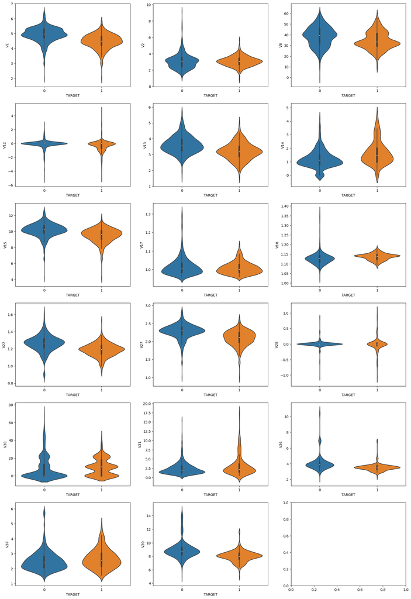

Furthermore we checked how features are correlated. We found that most features had weak correlation whether it was positive or negative one. The strongest positive correlation equal to 0.92 was observed between V15 and V27, while the strongest negative correlation equal to -0.79 was observed for V18 and V22. The full correlation matrix is presented below.

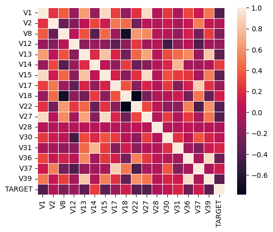

```
Strongest positive correlation equal to 0.92 was observed between V15 and V27.
Strongest negative correlation equal to -0.79 was observed between V18 and V22.
```

We split dataset into training and validation datasets 80:20. We perform feature scaling using `sklearn.preprocessing.StandardScaler` as it is known to be good practice for classification tasts. However for tabPFN we will be using uncaled data as should be done according to documentation.

# Logistic regression

We perform logistic regression using `sklearn.linear_model.LogisticRegression` model using Limited-memory Broyden-Fletcher-Goldfarb-Shanno (LBFGS) solver.

```
PPV: 0.71
TRP: 0.76
ACC: 0.85
F1: 0.74
MCC: 0.63
              precision    recall  f1-score   support

           0       0.91      0.88      0.89       152
           1       0.71      0.76      0.74        59

    accuracy                           0.85       211
   macro avg       0.81      0.82      0.82       211
weighted avg       0.85      0.85      0.85       211
```

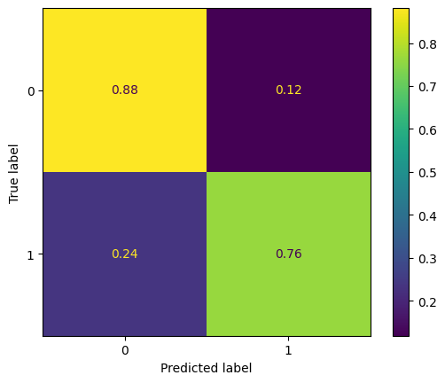

# SVC

We performed classification using Suppert Vector Machine Classifier (SVC) with radial basis function (RBF) kernel.

```
PPV: 0.67
TRP: 0.8
ACC: 0.83
F1: 0.73
MCC: 0.62
              precision    recall  f1-score   support

           0       0.91      0.85      0.88       152
           1       0.67      0.80      0.73        59

    accuracy                           0.83       211
   macro avg       0.79      0.82      0.80       211
weighted avg       0.85      0.83      0.84       211
```

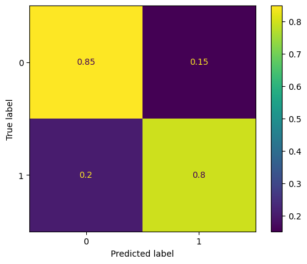

# Random Forest Decision Tree (RFDT)

We performed classification with Random Forest Classifier using `sklearn.ensemble.RandomForestClassifier` with `n_estimators = 300` and `max_depth = None`, so that nodes are expanded until all leaves are pure or until all leaves contain less than min_samples_split samples.

```
PPV: 0.71
TRP: 0.88
ACC: 0.87
F1: 0.79
MCC: 0.7
              precision    recall  f1-score   support

           0       0.95      0.86      0.90       152
           1       0.71      0.88      0.79        59

    accuracy                           0.87       211
   macro avg       0.83      0.87      0.85       211
weighted avg       0.88      0.87      0.87       211
```

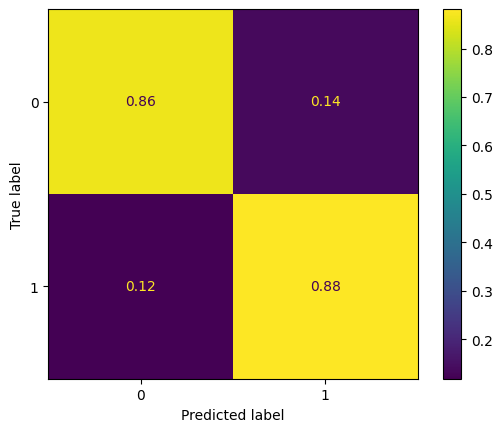

# Boosting Decision Tree (BDT)

We performed classification using Boosting Decision Tree (BDT) created with `sklearn.ensemble.GradientBoostingClassifier` for `n_estimators = 100`.

```
PPV: 0.69
TRP: 0.92
ACC: 0.86
F1: 0.79
MCC: 0.7
              precision    recall  f1-score   support

           0       0.96      0.84      0.90       152
           1       0.69      0.92      0.79        59

    accuracy                           0.86       211
   macro avg       0.83      0.88      0.84       211
weighted avg       0.89      0.86      0.87       211
```

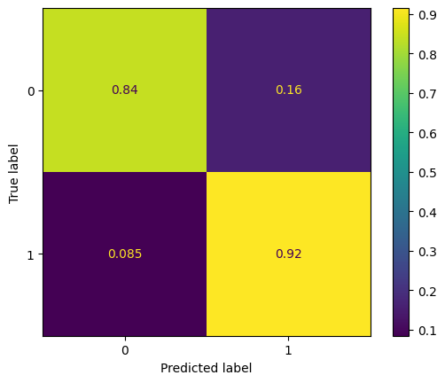

# Neural Network Classification

Then we used BCE Loss for SGD performed for 500 epochs, learning rate = 0.01 and batch size = 64.

```
epoch 0	loss : 0.9099029898643494	 accuracy : 0.3459715639810427
epoch 50	loss : 0.4259320795536041	 accuracy : 0.8056872037914692
epoch 100	loss : 0.33577656745910645	 accuracy : 0.8246445497630331
epoch 150	loss : 0.283983051776886	 accuracy : 0.8341232227488151
epoch 200	loss : 0.2539907991886139	 accuracy : 0.8625592417061612
epoch 250	loss : 0.23328812420368195	 accuracy : 0.8672985781990521
epoch 300	loss : 0.21606767177581787	 accuracy : 0.8672985781990521
epoch 350	loss : 0.20552082359790802	 accuracy : 0.8767772511848341
epoch 400	loss : 0.19684402644634247	 accuracy : 0.8767772511848341
epoch 450	loss : 0.18873126804828644	 accuracy : 0.8767772511848341
```

```
PPV: 0.74
TRP: 0.83
ACC: 0.87
F1: 0.78
MCC: 0.7
              precision    recall  f1-score   support

           0       0.93      0.89      0.91       152
           1       0.74      0.83      0.78        59

    accuracy                           0.87       211
   macro avg       0.84      0.86      0.85       211
weighted avg       0.88      0.87      0.87       211
```

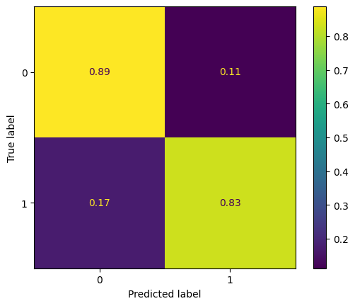

# TabPFN

We performed classification using tabPFN classifier with `N_ensemble_configurations=18`.

```
Loading model that can be used for inference only
Using a Transformer with 25.82 M parameters
Accuracy 0.8341232227488151
```

```
PPV: 0.68
TRP: 0.76
ACC: 0.83
F1: 0.72
MCC: 0.6
              precision    recall  f1-score   support

           0       0.90      0.86      0.88       152
           1       0.68      0.76      0.72        59

    accuracy                           0.83       211
   macro avg       0.79      0.81      0.80       211
weighted avg       0.84      0.83      0.84       211
```

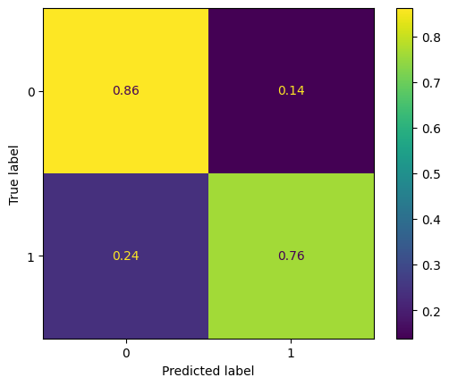

# Comparing results

We used following metrics to compare models performance:

- Accuracy ($ACC$),
- Precision ($PPV$),
- Sensivity ($TRP$),
- F1 score ($F1$),
- Matthews correlation coefficient ($MCC$).

All of the results are presented in the table below.

Moreover, this division can be infered from ROC curve analysis, which is presented in the figure below. The BDT has the highest AUC (area under curve) value equal to 0.879, while tabPFN has the lowest equal to 0.812.

This shows that decision tree models as well as neural networks seem to better understand and describe patterns present in dataset, thus yield better classification performance.

|  | LR | SVC | RFDT | BDT | NNC | tabPFN |
| --- | --- | --- | --- | --- | --- | --- |
| ACC | 0.85 | 0.83 | 0.87 | 0.86 | 0.87 | 0.83 |
| PPV | 0.71 | 0.67 | 0.71 | 0.69 | 0.74 | 0.68 |
| TRP | 0.76 | 0.80 | 0.88 | 0.92 | 0.83 | 0.76 |
| F1 | 0.74 | 0.73 | 0.79 | 0.79 | 0.78 | 0.72 |
| MCC | 0.63 | 0.62 | 0.70 | 0.70 | 0.70 | 0.60 |

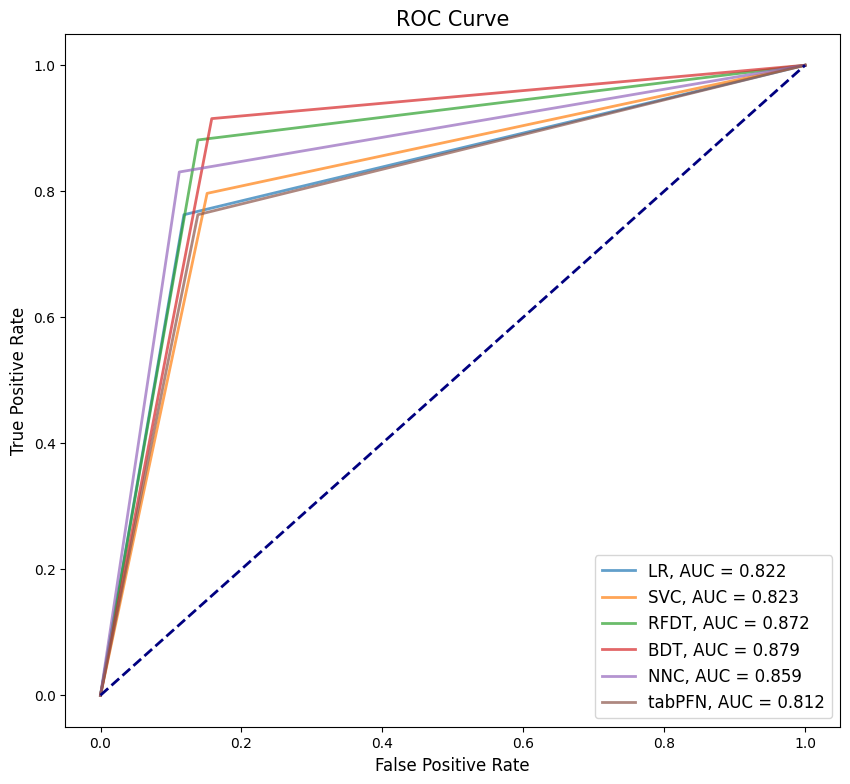